# Calculate Volatility and Moving Average

To calculate the daily log returns i need the NumPy library. For the purpose here, we will not explore the depths of NumPy, all i need is to apply the log-function on full column in DataFrame. i also use matplotib for visualize

```python
import pandas_datareader.data as web
bbni = web.DataReader('BBNI.JK', 'yahoo', start='2021-01-01', end='2022-01-01')
bbni
import matplotlib.pyplot as plt
%matplotlib notebook
import numpy as np
```

```python
bbni.rename(columns={'Adj Close': 'Price'}, inplace=True)
```

```python
bbni['%-chg'] = bbni['Price'].pct_change()
```

### First creates a column called with the daily Log returns of the Price.

```python
bbni['Log returns'] = np.log(bbni['Price']/bbni['Price'].shift())
```

```python
bbni['Log returns'].std()
```

```
0.02049947477928354
```

```python
Volatility = bbni['Log returns'].std()*252**.5
```

```python
Volatility
```

```
0.3254190736405496
```

```python
str_vol = str(round(Volatility, 2)*100)
```

```python
str_vol
```

```
'33.0'
```

### Visualize

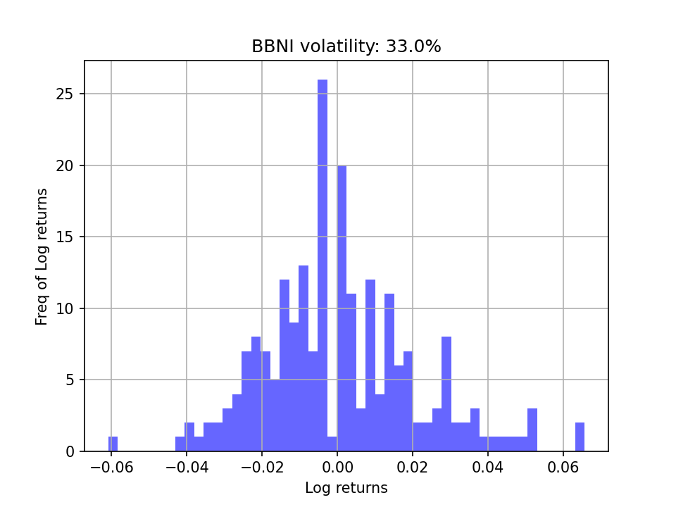

```python
Fig, ax = plt.subplots()
bbni['Log returns'].hist(ax=ax, bins=50, alpha=0.6, color='b')
ax.set_xlabel("Log returns")
ax.set_ylabel("Freq of Log returns")
ax.set_title("BBNI volatility: " + str_vol + "%")
```

## The moving average

In trading, there is the term Moving Average (MA). Moving Average is an indicator that calculates the average price of an asset over a certain period, then connects it in the form of a line. to know how to calculate and find MA in python we use "rolling(...)"

```python
bbni['MA10'] = bbni['Price'].rolling(10).mean()
```

```python
bbni.tail()
```

| Date | High | Low | Open | Close | Volume | Price | %-chg | Log returns | MA10 |
| --- | --- | --- | --- | --- | --- | --- | --- | --- | --- |
| 2021-11-15 | 6925.0 | 6800.0 | 6850.0 | 6800.0 | 24898400.0 | 6800.0 | -0.014493 | -0.014599 | 6967.5 |
| 2021-11-16 | 6950.0 | 6750.0 | 6800.0 | 6875.0 | 19247400.0 | 6875.0 | 0.011029 | 0.010969 | 6975.0 |
| 2021-11-17 | 7000.0 | 6900.0 | 6950.0 | 7000.0 | 20336900.0 | 7000.0 | 0.018182 | 0.018019 | 6972.5 |
| 2021-11-18 | 7000.0 | 6900.0 | 7000.0 | 6925.0 | 10818300.0 | 6925.0 | -0.010714 | -0.010772 | 6965.0 |
| 2021-11-19 | 7050.0 | 6925.0 | 6950.0 | 7025.0 | 23986600.0 | 7025.0 | 0.014440 | 0.014337 | 6972.5 |

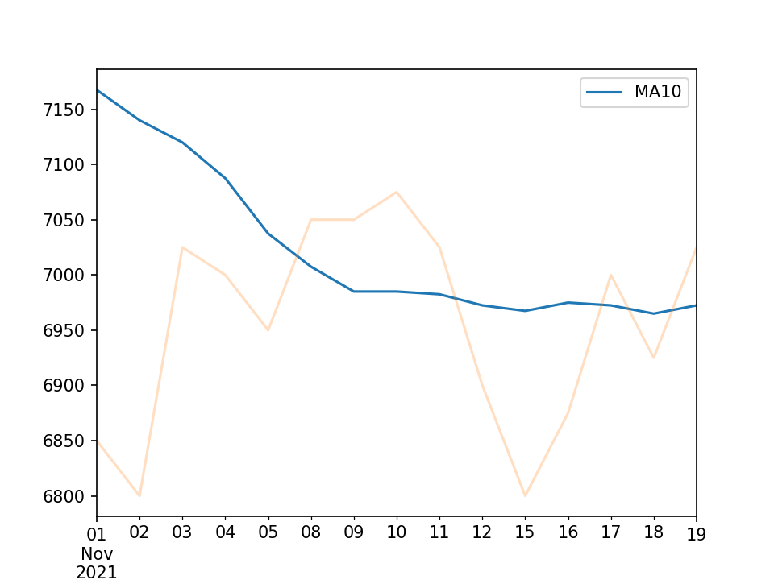

```python
fig, ax = plt.subplots()
bbni[['MA10']].loc['2021-11-01':].plot(ax=ax)
bbni['Price'].loc['2021-11-01':].plot(ax=ax, alpha=0.25)
```